# QMSS G5063 Final Project

Thomas Brambor

2024-02-21

# Final Group Project

### Goals of the Project

The goal of the final project for the course is to develop a data visualization project in groups of 3-4 students. The task is to closely engage with one or more sources of data to develop a consistent and (at least partially) interactive visual display of some of its main patterns. The results will be presented in the form of a **website** and an accompanying **project book**.

You will analyze data of your own choosing and report the results using (one or more of)

1. static images based on `ggplot2`,
2. maps using geospatial data,
3. visualizations of text analyses
4. network visualizations

and prepare a **hosted, interactive display of some of your visualizations** by **making use of some of the technical abilities you acquired throughout the course**. Of course, you are welcome to go beyond the tools offered in the course as well. However, the focus of the project (and grading) should be on the tools conveyed in this course.

### Data

For the final project, your data should:

1. be a **larger dataset to allow analysis in different forms**
2. contain at best one (or more) of the following elements
   - some geographic identifiers (cities, addresses. lat-long etc.) to allow mapping
   - some text to allow simple text analyses
   - contain a network matrix (or item relationships) to plot visual networks

I suggest relying on data that you either put together yourself from existing datasets,  
and/or using some API to collect the data you need from an online source (e.g. Twitter, new sources etc.). Using a single off-the-shelf dataset is possible but often results in projects that are harder to distinguish (for prospective employers) from existing analyses on the internet.

### Choice of Topic and Proposal

You are free to choose the topic and type of data. To make sure you are on the right track, we ask you to submit a proposal which should include the following information:

- Title of the project (and self-assigned group letter)
- Names of all project participants (including emails)
- Brief description of the proposed visualizations / analyses
- Links to data sources / API etc.
- Outline briefly which types of visualizations you plan to use.
- Are there any significant hurdles that you have doubts about? Would not solving them render the project incomplete?

# Submission

### Process Book

Part of the project is a **process book** in which you note (ideally as you go along) how your thinking developed, perhaps including some plots that you later discarded, some (handwritten) sketches of how you imagine the final design etc.

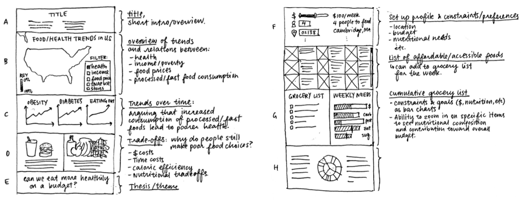

This is not meant as a running log of all the things you did. Instead, it is meant to capture the evolution of your project and provide the teaching team with an insight into the choices you made, visualizations you chose vs. others that you chose to abandon etc.

### Project Web Site

The goal for the final output of each group project is a visually appealing, easy to use, informative, and (partially) interactive website. In the initial development of the project, feel free to keep individual results / graphs etc. in separate, self-contained web pages with visualizations (and maybe text, other info, some links etc.). Towards the end of the course, we will cover how to combine these separate pages to make a simple final project website and host it.

### Final Presentations

Depending on the number of projects, I would like to aim to present all projects in-class. I will be asking that each group prepares a short presentations highlighting the topic of their project, explaining some of their visualization choices, explaining important data analyses choices (and/or pitfalls), and suggesting on where one could go next or how to improve.

# General Notes

### Communication / Github

As with all assignments in the course, I want you to **use GitHub for working on and submitting the assignment**.

In fact, since multiple people will be working in a group, this will be the ideal way to **keep track of your work** and allow the teaching staff to interact with you easily on suggestions, improvements, and coding issues.

In addition, I recommend that you start a private chat group on Campuswire which will include all members of your group and can also be a place to ask questions to the instructors with direct `@` mentions.

### Feedback to another project

Each student will provide comments about the visualizations used in one other project. These comments can then be used to inform some final adjustments before submission. We will post links to all final projects on a website. Everyone will receive an email specifying which project they should comment on and the comments will be anonymous and be shared on Github.

### How is the final project evaluated?

1. **Visualization**
- Is your visualization effective in answering the questions you intended to address? Is the storytelling clear?
- Do the visualizations follow visualization principles?
- Is it informative and interesting for a user?
- Does it allow some sensible interactive exploration?
2. **Implementation**
- What is the quality of your implementation?
- Is it appropriately polished, robust, and reliable?
3. **Presentation**
- Are your web site and presentation clear, engaging, and effective?

### Submission and Due Dates

Please follow the instructions to submit your project. For the final project, please use your submission issue to tag the teaching team. On GitHub, please use the group project repository to submit all materials.

The proposal is due on Wednesday, March 6.